# Dealing with Dirty Data Final Project

Michael Wakeman

1/9/2021

# Introduction

For my final project, I chose to utilize the “NYC Wi-Fi Hotspot Locations” data set from [NYC Open Data](https://data.cityofnewyork.us/City-Government/NYC-Wi-Fi-Hotspot-Locations/yjub-udmw), which was retrieved on Jan. 7, 2021 as a .csv file. The data set includes information on WiFi spots within NYC, including their location, type, and provider information. I chose to call this data set `Wifi`. This data set was last updated Feb. 7, 2020.

I chose this data set as it seemed like a fun one to do and had opportunities to apply the different cleaning techniques we’ve learned in class (such as dates, missing variables, etc.). It is also a fairly large data set, which was a requirement I had trouble clearing with other interesting data sets.

I would like to learn about the geographic distribution of WiFi locations in NYC, including by neighborhood and borough. This would also include where WiFi locations are most available and least available. I would also like to know about accessibility to these sites, are they mostly free?

### Data Exploration

Here are the initial variables in the `Wifi` data set. I chose to rename `Council Distrcit` to `Council District` since it appeared to be a spelling mistake. There are 29 columns and 3319 rows in the initial data set.

```r
ncol(Wifi)
```

```
## [1] 29
```

```r
nrow(Wifi)
```

```
## [1] 3319
```

## Variable Definitions

Here is a table documenting the original variables and their definitions taken from NYC Open Data.

NYC Wi-Fi Hotspot Locations Documentation

| Variable | Definition |
| --- | --- |
| OBJECTID | Identification number automatically generated by map software ArcMap. |
| Borough | Borough of New York City. MN = Manhattan, BX = Bronx, BK = Brooklyn, QU = Queens, SI = Staten Island. |
| Type | Type of WiFi provided by franchise. |
| Provider | Franchise who is providing the WiFi connection. |
| Name | The name of the location where the WiFi is located. |
| Location | A brief description of where the WiFi point is. |
| Latitude | Points that fall North or South of the Equator, expressed in degrees. |
| Longitude | Points that fall East or West of the Prime Meridian, expressed in degrees. |
| X | A horizontal value where a point is located. |
| Y | A vertical value where a point is located. |
| Location_T | The type of location that a WiFi hotspot is present in. |
| Remarks | Comments describing a specific hotspot or location. |
| City | The city in which a hotspot is located. |
| SSID | The name of the WiFi seen on people's devices. |
| SourceID | A LinkNYC Kiosk's unique identification number. |
| Activated | The approximated date that this Wi-Fi site went active. |
| BoroCode | The New York City borough where the hotspots are located. 1 = Manhattan, 2 = Bronx, 3 = Brooklyn, 4 = Queens, 5 = Staten Island. |
| Borough Name | The New York City borough where the hotspots are located. |
| Neighborhood Tabulation Area Code (NTACODE) | Four (4) digit code assigned to neighborhoods to differentiate NYC's five boroughs. |
| Neighborhood Tabulation Area (NTA) | Neighborhood identifiers to differentiate NYC's five boroughs. |
| Council District | NYC City Council District number. |
| Postcode | United States Postal Service Zip Code (5-digits). |
| BoroCD | New York City Borough plus Community Board Numbers. |
| Census Tract | 2010 U.S. Census data based on location. |
| BCTCB2010 | Combined value of Borough CD and Census 2010. |
| BIN | Building Identification Number. |
| BBL | Borough Block Lot. |
| DOITT_ID | Identification number automatically generated by GIS Developer map sites. |
| Location (Lat, Long) | Combination of the latitude and longitude values. |

Table 1.1  
Source: NYC Open Data, 2020.

### Initial Data Recoding

The data includes `NA` values within several variables. In addition, `BBL`, `BIN`, `Name`, and `SourceID` contain observations of 0. Given their definitions these are most likely missing values as well. For this reason I recoded `0` within each of these variables as `NA`.

Additionally, `Activated` contains dates. This includes values of `09/09/9999` which I also recoded as `NA`.

The `Borough` variable did not match the variable documentation from NYC Open Data. Instead of using character abbreviations they were inputted as numbers. I chose to match the original documentation and recode these to character abbreviations.

# Initial Data Cleaning

I used a sapply loop function to calculate the sum of missing observations for each variable. Of the 29 variables, `Activated`, `BBL`, `BIN`, `Name`, `Remarks`, and `SourceID` contain missing data. These variables all have several hundred missing observations, so it would not be suitable to drop them.

I then created binary flags for missing data within each of the six variables using ifelse statements.

```r
sapply(Wifi, function(x) sum(is.na(x)))
```

```
##                                    OBJECTID
##                                           0
##                                     Borough
##                                           0
##                                        Type
##                                           0
##                                    Provider
##                                           0
##                                        Name
##                                         269
##                                    Location
##                                           0
##                                    Latitude
##                                           0
##                                   Longitude
##                                           0
##                                           X
##                                           0
##                                           Y
##                                           0
##                                  Location_T
##                                           0
##                                     Remarks
##                                         548
##                                        City
##                                           0
##                                        SSID
##                                           0
##                                    SourceID
##                                        1405
##                                   Activated
##                                        1497
##                                    BoroCode
##                                           0
##                                Borough Name
##                                           0
## Neighborhood Tabulation Area Code (NTACODE)
##                                           0
##          Neighborhood Tabulation Area (NTA)
##                                           0
##                            Council District
##                                           0
##                                    Postcode
##                                           0
##                                      BoroCD
##                                           0
##                                Census Tract
##                                           0
##                                   BCTCB2010
##                                           0
##                                         BIN
##                                         837
##                                         BBL
##                                         576
##                                    DOITT_ID
##                                           0
##                        Location (Lat, Long)
##                                           0
```

```r
Wifi$BF_Activated <- ifelse(is.na(Wifi$Activated) == TRUE, 1, 0)
Wifi$BF_Name <- ifelse(is.na(Wifi$Name) == TRUE, 1, 0)
Wifi$BF_BIN <- ifelse(is.na(Wifi$BIN) == TRUE, 1, 0)
Wifi$BF_Remarks <- ifelse(is.na(Wifi$Remarks) == TRUE, 1, 0)
Wifi$BF_SourceID <- ifelse(is.na(Wifi$SourceID) == TRUE, 1, 0)
Wifi$BF_BBL <- ifelse(is.na(Wifi$BBL) == TRUE, 1, 0)
```

Along with the total count of missing observations for each variable, I found the percent of missing data within each variable. `Activated` had the highest rate of missing data, `45.1`. Of the other variables with missing data, their rates were also significantly high.

```r
sapply(Wifi, function(x) {
  (sum(is.na(x)) / length(x)) * 100
}
)
```

```
##                                    OBJECTID
##                                    0.000000
##                                     Borough
##                                    0.000000
##                                        Type
##                                    0.000000
##                                    Provider
##                                    0.000000
##                                        Name
##                                    8.104851
##                                    Location
##                                    0.000000
##                                    Latitude
##                                    0.000000
##                                   Longitude
##                                    0.000000
##                                           X
##                                    0.000000
##                                           Y
##                                    0.000000
##                                  Location_T
##                                    0.000000
##                                     Remarks
##                                   16.510997
##                                        City
##                                    0.000000
##                                        SSID
##                                    0.000000
##                                    SourceID
##                                   42.332028
##                                   Activated
##                                   45.103947
##                                    BoroCode
##                                    0.000000
##                                Borough Name
##                                    0.000000
## Neighborhood Tabulation Area Code (NTACODE)
##                                    0.000000
##          Neighborhood Tabulation Area (NTA)
##                                    0.000000
```

[output cut: 15 more lines]

```
##                                    0.000000
##                        Location (Lat, Long)
##                                    0.000000
##                                BF_Activated
##                                    0.000000
##                                     BF_Name
##                                    0.000000
##                                      BF_BIN
##                                    0.000000
##                                  BF_Remarks
##                                    0.000000
##                                 BF_SourceID
##                                    0.000000
##                                      BF_BBL
##                                    0.000000
```

I then started modifying individual variables. I began by creating an ID variable. Although there are two other ID variables, these are based on specific systems and skip some entries. In order to easily reference data I wanted a complete ID row. I chose to name this variable `ID`.

As mentioned previously, the only date within the data set is `Activated`. I used the Lubridate package to recode this variable as a properly formatted date.

Finally, `Census Tract` and `BCTCB2010` contained the same information, so I removed the latter column.

I then started modifying the `City` and `Borough Name` variables. These two share observations for most rows. However, there are some discrepancies. I analyzed each borough to find these differences. Of the five boroughs, there were no errors with the Bronx, Brooklyn, or Staten Island.

Manhattan is the only borough to correspond with `New York` as the city. The other boroughs have themselves listed as the city. To maintain this pattern I recoded `New York` to `Manhattan` (and obviously NYC is the city for all of these locations). Additionally, there was one occurrence where Manhattan corresponded with `Brooklyn` as a city. I interpreted this as an error and recoded it to `Manhattan` as well.

Finally, Queens has many interesting corresponding values in `City`. This includes errors, such as other boroughs like `Brooklyn`. It also includes smaller cities like `Long Island City`. No other borough has values like these, which differ from their corresponding NTA (neighborhood) values. I decided these were most likely errors. Recoding these values to match the borough, as the others do, would make `City` the same as `Borough`. For that reason I chose to just remove the `City` variable from the data set.

The data set includes latitude and longitude values along with a combined variable, `Location (Lat, Long)`. I verified its contents by recoding it using combined `Latitude` and `Longitude` values.

```r
LongLat1 <- str_c(Wifi$Latitude, Wifi$Longitude, sep = ", ")
LongLat2 <- str_c("(", LongLat1, ")", sep = "")
Wifi$`Location (Lat, Long)` <- LongLat2
```

Lastly, I recoded several categorical variables as factors. These variables were `BoroCode`, `Borough`, `Borough Name`, `Location_T`, `Provider`, and `Type`.

```r
Wifi$Borough <- as.factor(Wifi$Borough)
Wifi$Type <- as.factor(Wifi$Type)
Wifi$Provider <- as.factor(Wifi$Provider)
Wifi$`Location_T` <- as.factor(Wifi$`Location_T`)
Wifi$`Borough Name` <- as.factor(Wifi$`Borough Name`)
Wifi$BoroCode <- as.factor(Wifi$BoroCode)
```

# String Cleaning

`Location_T` is a string variable that includes information on the type of location. This variable contained several observations that were similar, such as `Indoor AP - South Management Office` and `Indoor AP - Community Center - Activity Rm 1`. I chose to recode these to be `Indoor` observations or other pre-existing categories.

I then created a binary `Indoor` variable to distinguish between indoor and outdoor WiFi locations using an ifelse statement.

Similarly, I created a `Subway` binary variable and verified its contents by using the `SSID` value was `TransitWirelessWiFi`, which I assume (based on its name) is used for all subway WiFi locations.

The data set also includes specific location and address information in the `Location` variable. I chose to create a mailing address variable for indoor locations using this information. I didn’t feel it was necessary to include outdoor locations, since their information is coded differently, such as with incomplete information, and it would not be useful to have a mailing address for an outdoor area or kiosk.

I created an `Indoor Address` variable from `Location`, choosing information for indoor locations and ignoring locations from providers that did not supply full address information.

I then separated the address strings into `Street Name` and `Street Number`. Finally, I created one binary variable to flag missing address information in these three variables.

```r
Wifi$IndoorAddress <- ifelse(Wifi$Indoor == 1 &
                             Wifi$Provider != "SPECTRUM" &
                             Wifi$Provider != "ALTICEUSA" &
                             Wifi$Provider != "Fiberless", Wifi$Location, NA)


address <- str_split(Wifi$IndoorAddress, " ", n = 2, simplify = TRUE)
Wifi$StreetNumber <- address[, 1]
Wifi$StreetName <- address[, 2]


Wifi$StreetName <- ifelse(!is.na(Wifi$StreetNumber) == TRUE, Wifi$StreetName, NA)


Wifi$BF_Address <- ifelse(is.na(Wifi$IndoorAddress) == TRUE |
                          is.na(Wifi$StreetNumber) == TRUE |
                          is.na(Wifi$StreetName) == TRUE, 1, 0)
```

Many of these WiFi locations had information on finding them in both `Name` and `Location`. I chose to combine these two variables into a `Directions` variable. This makes observations like, `Crotona Park, (PICNIC AREA) INSIDE PARK WEST OF PLAYGROUND` which is a more specific location than either individually.

I chose to leave the value as `NA` if the corresponding `Name` value was also missing. I also chose to ignore those with `Provider` values of `LinkNYC - Citybridge` and `Manhattan Down Alliance` as they only had names without geographic information (ex. `mn-03-123802`). I then created a binary flag for missing data in the new variable.

`Remarks` includes information on Wi-Fi speed and location. I took the information concerning internet speed and created a new variable, `Quality (MB)` along with a binary flag for missing observations. It should be noted that `Remarks` has many missing observations, so this not be interpreted as complete information on internet quality for all providers.

# Other Variable Formation

I chose to make a binary flag using `Type` to quickly distinguish the type of WiFi provided, `Free`. This gives a value of 1 for free locations.

Here is a table of the variables in the original data set as well as the new variables created while leaning it.

NYC Wi-Fi Hotspot Locations Documentation

| Variable | Definition |
| --- | --- |
| OBJECTID | Identification number automatically generated by map software ArcMap. |
| Borough | Borough of New York City. MN = Manhattan, BX = Bronx, BK = Brooklyn, QU = Queens, SI = Staten Island. |
| Type | Type of WiFi provided by franchise. |
| Provider | Franchise who is providing the WiFi connection. |
| Name | The name of the location where the WiFi is located. |
| Location | A brief description of where the WiFi point is. |
| Latitude | Points that fall North or South of the Equator, expressed in degrees. |
| Longitude | Points that fall East or West of the Prime Meridian, expressed in degrees. |
| X | A horizontal value where a point is located. |
| Y | A vertical value where a point is located. |
| Location_T | The type of location that a WiFi hotspot is present in. |
| Remarks | Comments describing a specific hotspot or location. |
| City | The city in which a hotspot is located. |
| SSID | The name of the WiFi seen on people's devices. |
| SourceID | A LinkNYC Kiosk's unique identification number. |
| Activated | The approximated date that this Wi-Fi site went active. |
| BoroCode | The New York City borough where the hotspots are located. 1 = Manhattan, 2 = Bronx, 3 = Brooklyn, 4 = Queens, 5 = Staten Island. |
| Borough Name | The New York City borough where the hotspots are located. |
| Neighborhood Tabulation Area Code (NTACODE) | Four (4) digit code assigned to neighborhoods to differentiate NYC's five boroughs. |
| Neighborhood Tabulation Area (NTA) | Neighborhood identifiers to differentiate NYC's five boroughs. |
| Council District | NYC City Council District number. |
| Postcode | United States Postal Service Zip Code (5-digits). |
| BoroCD | New York City Borough plus Community Board Numbers. |
| Census Tract | 2010 U.S. Census data based on location. |
| BCTCB2010 | Combined value of Borough CD and Census 2010. |
| BIN | Building Identification Number. |
| BBL | Borough Block Lot. |
| DOITT_ID | Identification number automatically generated by GIS Developer map sites. |
| Location (Lat, Long) | Combination of the latitude and longitude values. |
| BF_Activated | Binary flag for missing information in Activated variable. |
| BF_Name | Binary flag for missing information in Name variable. |
| BF_BIN | Binary flag for missing information in BIN variable. |
| BF_Remarks | Binary flag for missing information in Remarks variable. |
| BF_SourceID | Binary flag for missing information in SourceID variable. |
| BF_BBL | Binary flag for missing information in BBL variable. |
| ID | Unique row ID generated in R. |
| Indoor | Binary flag to distinguish between indoor and outdoor locations, where 1 is indoors. |
| Subway | Binary flag to distinguish subway locations, where 1 is within subways. |
| Indoor Address | Separated mailing addresses for indoor locations. |
| StreetNumber | Street number for indoor locations. |
| StreetName | Street name for indoor locations |
| BF_Address | Binary flag for missing information Indoor Address, StreetNumber, StreetName. |
| Directions | Combined Location and Name variable. |
| BF_Directions | Binary flag for missing information in Directions variable. |
| Quality (MB) | Internet speed provided by WiFi location in MB. |
| BF_Quality (MB) | Binary flag for missing information in Quality (MB) variable. |
| Free | Binary flag to distinguish free WiFi locations, where 1 is free |

Table 1.2  
Source: NYC Open Data, 2020.

# Analysis

After cleaning the `Wifi` data set I wanted to answer my initial questions of interest.

I created two data frames to find what the distribution of providers by neighborhood (NTA) and borough. This allowed me to see what providers operated in each borough and neighborhood as well as the total number of providers in each locality.

Using similar code I created two data frames to find the most common type of WiFi location in each borough and NTA along with the breakdown of type of site in each borough and NTA.

I then found the breakdown of indoor and outdoor locations for each NTA and borough.

I began working with the `Quality (MB)` variable. I found the average speed within each borough, however only a handful of providers supply quality information. Although there were some differences, the speeds were relatively uniform with most boroughs around 1 GB. I believe the lack of significant differences between boroughs to be due to missing data on WiFi speed.

```r
BoroughSpeed <- Wifi %>%
  select(`Borough Name`, `Quality (MB)`) %>%
  group_by(`Borough Name`) %>%
  filter(!(is.na(`Quality (MB)`)) == TRUE) %>%
  mutate(Av.Speed = mean(`Quality (MB)`)) %>%
  select(-`Quality (MB)`) %>%
  distinct()
BoroughSpeed
```

```
## # A tibble: 5 x 2
## # Groups:   Borough Name [5]
##   `Borough Name` Av.Speed
##   <fct>             <dbl>
## 1 Manhattan          975.
## 2 Brooklyn          1000
## 3 Staten Island     1000
## 4 Queens             944.
## 5 Bronx             1000
```

```r
IndoorQualityData <- Wifi %>%
  select(Indoor, `Quality (MB)`) %>%
  filter(!is.na(`Quality (MB)`) == TRUE & Indoor == 1)

IndoorQuality <- mean(IndoorQualityData$`Quality (MB)`)
IndoorQuality
```

```
## [1] 23.82353
```

```r
OutdoorQualityData <- Wifi %>%
  select(Indoor, `Quality (MB)`) %>%
  filter(!is.na(`Quality (MB)`) == TRUE & Indoor == 0)

OutdoorQuality <- mean(OutdoorQualityData$`Quality (MB)`)
OutdoorQuality
```

```
## [1] 984.7891
```

```r
FreeQualityData <- Wifi %>%
  select(Free, `Quality (MB)`) %>%
  filter(!is.na(`Quality (MB)`) == TRUE & Free == 1)

FreeQuality <- mean(FreeQualityData$`Quality (MB)`)
FreeQuality
```

```
## [1] 976.2539
```

```r
NotFreeQualityData <- Wifi %>%
  select(Free, `Quality (MB)`) %>%
  filter(!is.na(`Quality (MB)`) == TRUE & Free == 0)

NotFreeQuality <- mean(NotFreeQualityData$`Quality (MB)`)
NotFreeQuality
```

```
## [1] NaN
```

# Tables

After making data frames I chose to present them in table and plot form to answer my questions of interest.

I took the previous data frame on provider information and used the gt package to make a table. The table gives a complete breakdown of the ISPs operating in each borough and the provider with the most sites in each borough. The table shows that there is a large difference in WiFi locations across NYC. Manhattan has over 1600 sites, while Staten Island has only 100. This makes sense given that Staten Island is relatively suburban compared to Manhattan. Additionally, LinkNYC is the most common ISP in four of the five boroughs, which I found surprising.

ISPs in NYC

WiFi ISP Distribution by NYC Borough (Feb. 2020)

[output not shown]

Table 2  
Source: NYC Open Data, 2020.

I used my data frame on indoor and outdoor WiFi locations to make another table. This summarizes the type of internet present in each neighborhood in NYC, grouped by borough. The table also shows what the most common type of location was in each neighborhood, along with the percentage of indoor locations.

Generally, it seems that most locations are outside. This is true between neighborhoods and also among those with higher amounts of WiFi locations. One downside of looking and neighborhoods is that it presents a visualization with small numbers. Overall, the percentage of indoor locations vary, with some neighborhoods completely indoors or completely outdoors There does not appear to be any trends between boroughs; they all appear to be predominantly outdoor locations.

WiFi Accessibility in NYC

WiFi Location by NYC Neighborhood (Feb. 2020)

[output not shown]

[output cut: 154 more lines]

Table 3  
Source: NYC Open Data, 2020.

# Plots

Finally, I created a plot using ggplot2 to summarize the cost of internet locations by borough. This bar plot displays the relative number of free, limited free, and partner sites within each borough. The plot also includes a column of total sites. This allows comparison of any types of locaitons as well as the total amount. Overall, Manhattan posseses the most sites by far. Additionally, almost all of these are free sites. The other boroughs, with the exception of Staten Island, also have a majority of free sites. Staten Island has more limited free than free sites.

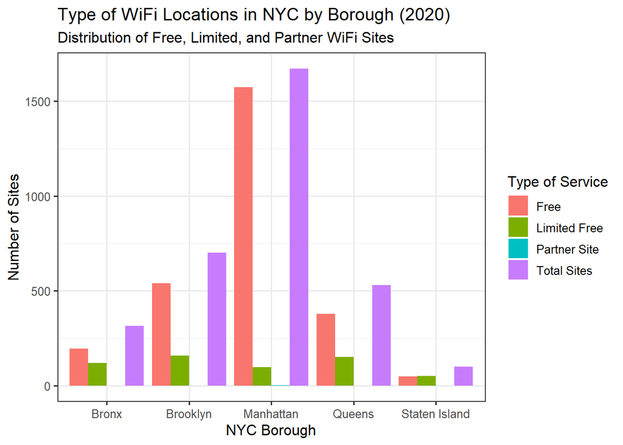

```r
NewCommonType.Borough <- CommonType.Borough %>%
  select(-Percent.Free, -Most_Common) %>%
  gather("Type", "Value", -`Borough Name`)

ggplot(NewCommonType.Borough, mapping = aes(x = `Borough Name`, y = Value, fill = Type)) +
  geom_col(position = "dodge",
           size = 0.5) +
  labs(title = "Type of WiFi Locations in NYC by Borough (2020)",
       subtitle = "Distribution of Free, Limited, and Partner WiFi Sites",
       fill = "Type of Service") +
  ylab("Number of Sites") +
  xlab("NYC Borough") +
  theme_bw(base_size = 12) +
  scale_fill_discrete(labels = c("Free",
                                "Limited Free",
                                "Partner Site",
                                "Total Sites"))
```

# Conclusions

Over the course of cleaning, analyzing, and displaying the `Wifi` data set I was able to answer my questions of interest. There were large variations in the geographic distribution of WiFi sites in NYC, including by neighborhood and borough. These differences included the quantity of locations in addition to the cost of access. Manhattan possesses a high-speed, free, and easily accessible network of WiFi locations, The other boroughs, with the exception of Staten Island, also possess generally free networks. These differences are most likely the result of community differences, including business needs and the extent of urban and suburban living.

Before working on this data set be aware that many of the most interesting variables, such as `Quality (MB)` lack information for many providers.